# Stock Market Analysis

## Companies - Tesla and Nio

## Submitted by - Abhishek Satayavir Sharma

## Roll no- 205320002

# 1. What was the change in price of the stock overtime?

In this section we'll go over how to handle requesting stock information with pandas, and how to analyze basic attributes of a stock.

```python
import pandas as pd
import numpy as np

import matplotlib.pyplot as plt
import seaborn as sns
sns.set_style('whitegrid')
%matplotlib inline

# For reading stock data from yahoo
from pandas_datareader.data import DataReader

# For time stamps
from datetime import datetime
```

```python
# The EV stocks we'll use for this analysis
ev_list = ['TSLA','NIO']
# Set up End and Start times for data grab
end = datetime.now()
start = datetime(end.year - 1, end.month, end.day)
Tesla=DataReader(ev_list[0],'yahoo',start,end);
Nio=DataReader(ev_list[1],'yahoo',start,end);
```

```python
# Summary Stats
Tesla.describe()
```

|  | High | Low | Open | Close | Volume | Adj Close |
| --- | --- | --- | --- | --- | --- | --- |
| count | 253.000000 | 253.000000 | 253.000000 | 253.000000 | 2.530000e+02 | 253.000000 |
| mean | 626.976545 | 598.679906 | 613.633463 | 613.777124 | 4.036751e+07 | 613.777124 |
| std | 138.741168 | 135.961652 | 137.786286 | 137.209702 | 2.587491e+07 | 137.209702 |
| min | 368.739990 | 329.880005 | 335.399994 | 330.209991 | 8.356002e+06 | 330.209991 |
| 25% | 479.040009 | 442.500000 | 459.023987 | 461.299988 | 2.346920e+07 | 461.299988 |
| 50% | 654.429993 | 621.289978 | 642.989990 | 644.219971 | 3.249670e+07 | 644.219971 |
| 75% | 713.179993 | 681.369995 | 700.000000 | 698.840027 | 4.787970e+07 | 698.840027 |
| max | 900.400024 | 871.599976 | 891.380005 | 883.090027 | 2.221262e+08 | 883.090027 |

```python
# General info
Tesla.head()
```

| Date | High | Low | Open | Close | Volume | Adj Close |
| --- | --- | --- | --- | --- | --- | --- |
| 2020-08-17 | 369.171997 | 334.566010 | 335.399994 | 367.127991 | 101211500.0 | 367.127991 |
| 2020-08-18 | 384.779999 | 369.022003 | 379.798004 | 377.417999 | 82372500.0 | 377.417999 |
| 2020-08-19 | 382.200012 | 368.242004 | 373.000000 | 375.705994 | 61026500.0 | 375.705994 |
| 2020-08-20 | 404.398010 | 371.411987 | 372.135986 | 400.365997 | 103059000.0 | 400.365997 |
| 2020-08-21 | 419.097992 | 405.010010 | 408.951996 | 409.996002 | 107448000.0 | 409.996002 |

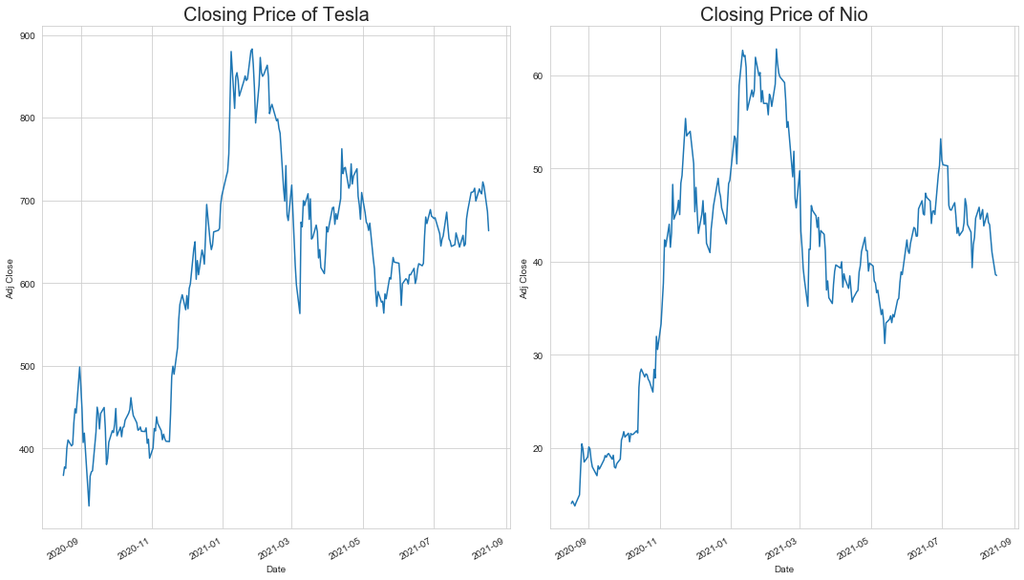

```python
# Let's see a historical view of the closing price
plt.figure(figsize=(15, 16))
#plt.subplots_adjust(top=1.25, bottom=1.2)
plt.subplot(2, 2, 1)
Tesla['Adj Close'].plot()
plt.ylabel('Adj Close',fontsize=10)
plt.xlabel('Date',fontsize=10)
plt.title("Closing Price of Tesla",fontsize=20);


plt.subplot(2,2,2)
Nio['Adj Close'].plot()
plt.ylabel('Adj Close',fontsize=10)
plt.xlabel('Date',fontsize=10)
plt.title(f"Closing Price of Nio",fontsize=20)

plt.tight_layout()
```

[figure not shown]

```python
# Now let's plot the total volume of stock being traded each day
plt.figure(figsize=(15, 7))
plt.subplots_adjust(top=1.25, bottom=1.2)
plt.subplot(2, 1, 1)
Tesla['Volume'].plot()
plt.ylabel('Volume')
plt.xlabel(None)
plt.title("Sales Volume for Tesla",fontsize=20)
plt.tight_layout()

plt.subplot(2, 1, 2)
Nio['Volume'].plot()
plt.ylabel('Volume')
plt.xlabel(None)
plt.title("Sales Volume for Tesla",fontsize=20)
plt.tight_layout()
```

Now that we've seen the visualizations for the closing price and the volume traded each day, let's go ahead and caculate the moving average for the stock.

# 2. What was the moving average of the two stocks?

```python
ma_day = [10, 20, 50,100]

for ma in ma_day:
    column_name = f"MA for {ma} days"
    Tesla[column_name] = Tesla['Adj Close'].rolling(ma).mean()
    Nio[column_name] = Nio['Adj Close'].rolling(ma).mean()
```

Now let's go ahead and plot all the additional Moving Averages

```python
# df.groupby("company_name").hist(figsize=(12, 12));
```

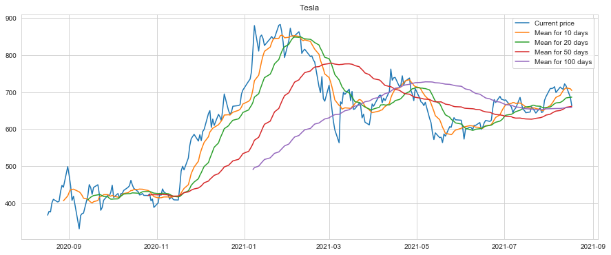

```python
plt.figure(figsize=(15,6))
plt.plot(Tesla[['Adj Close', 'MA for 10 days', 'MA for 20 days', 'MA for 50 days','MA for 100 days']])
plt.legend(['Current price','Mean for 10 days','Mean for 20 days','Mean for 50 days','Mean for 100 days'])
plt.title('Tesla')
plt.show()
```

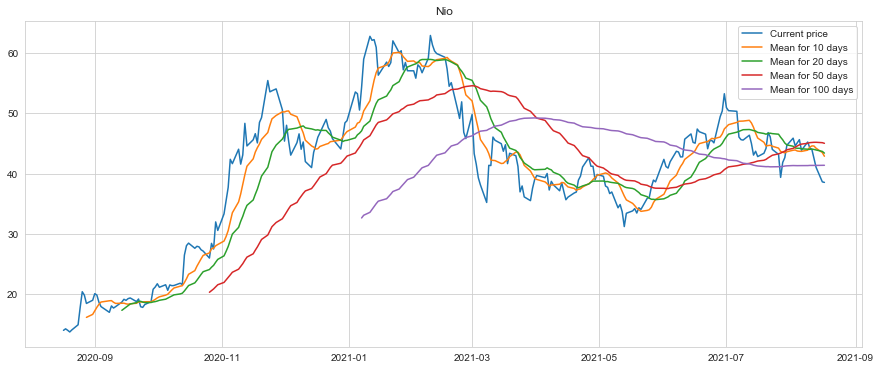

```python
plt.figure(figsize=(15,6))
plt.plot(Nio[['Adj Close', 'MA for 10 days', 'MA for 20 days', 'MA for 50 days','MA for 100 days']])
plt.legend(['Current price','Mean for 10 days','Mean for 20 days','Mean for 50 days','Mean for 100 days'])
plt.title('Nio')
plt.show()
```

# 3. What was the daily return of the stock on average?

Now that we've done some baseline analysis, let's go ahead and dive a little deeper. We're now going to analyze the risk of the stock. In order to do so we'll need to take a closer look at the daily changes of the stock, and not just its absolute value. Let's go ahead and use pandas to retrieve the daily returns for the Tesla and Nio stock.

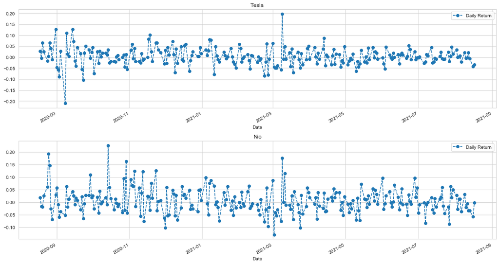

```python
# We'll use pct_change to find the percent change for each day
Tesla['Daily Return'] = Tesla['Adj Close'].pct_change()
Nio['Daily Return'] = Nio['Adj Close'].pct_change()

# Then we'll plot the daily return percentage
fig, axes = plt.subplots(nrows=2, ncols=1)
fig.set_figheight(8)
fig.set_figwidth(15)

Tesla['Daily Return'].plot(ax=axes[0], legend=True, linestyle='--', marker='o')
axes[0].set_title('Tesla')

Nio['Daily Return'].plot(ax=axes[1], legend=True, linestyle='--', marker='o')
axes[1].set_title('Nio')

fig.tight_layout()
```

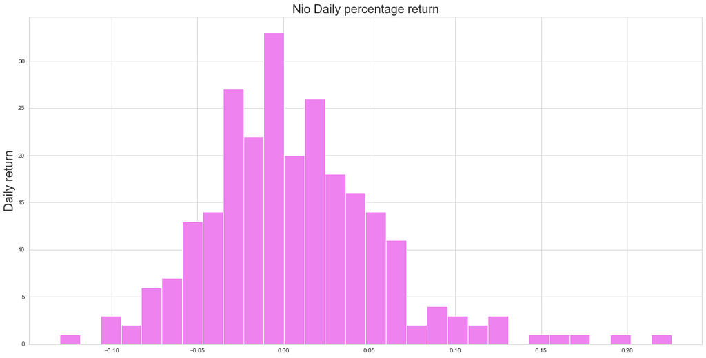

```python
plt.figure(figsize=(20,10))
Nio['Daily Return'].hist(bins=30,color='violet')
plt.xlabel(None)
plt.ylabel('Daily return',fontsize=20)
plt.title('Nio Daily percentage return',fontsize=20)
```

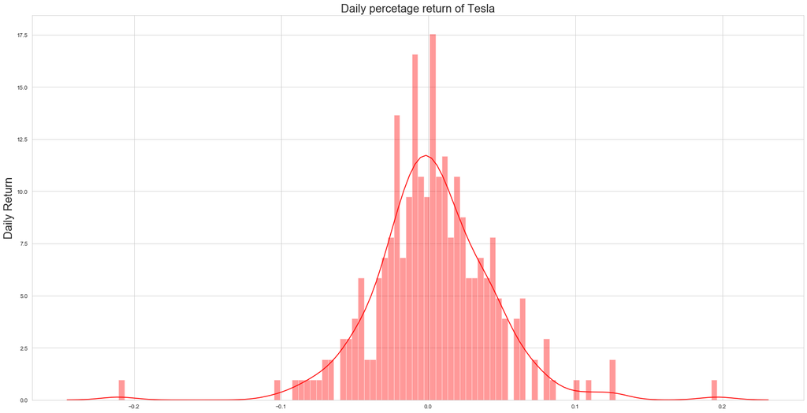

```python
# Note the use of dropna() here, otherwise the NaN values can't be read by seaborn
plt.figure(figsize=(20,10))
sns.distplot(Tesla['Daily Return'].dropna(), bins=100, color='red')
plt.ylabel('Daily Return',fontsize=20)
plt.xlabel(None,fontsize=20)
plt.tight_layout()
plt.title('Daily percetage return of Tesla',fontsize=20)
```